# NB and Logistic Regression Project

## 12. Logistic Regression with Grid Search post Forward Subset Selection with Top 20 Features

```
training the model..
Fitting 3 folds for each of 60 candidates, totalling 180 fits
Done


training_time(HH:MM:SS.ms) - 0:01:07.605400


Predicting test data
Done


testing time(HH:MM:SS:ms) - 0:00:00.004998


---------------------
|      Accuracy      |
---------------------

    0.9392565729827742


--------------------
| Confusion Matrix |
--------------------

 [[422   0   0   0   0   0]
 [  1 335  50   0   0   0]
 [  0  46 366   0   0   0]
 [  0   0   0 360   4   4]
 [  0   0   0   4 284   8]
 [  0   0   0   8   9 305]]
```

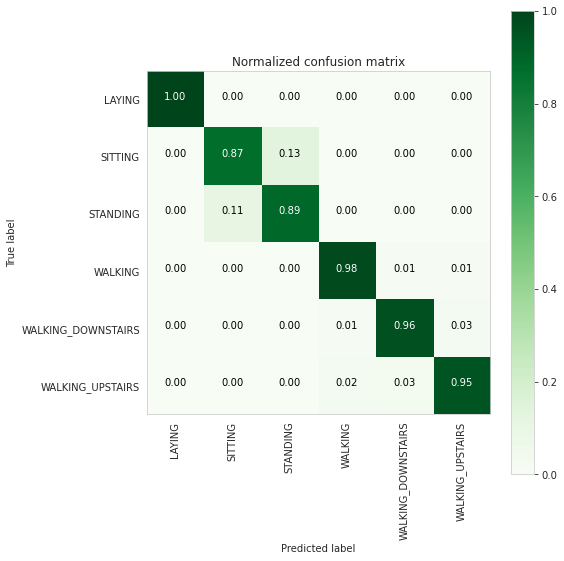

```
No artists with labels found to put in legend.  Note that artists whose label start with an underscore are ignored when legend() is called with no argument.
```

```
-------------------------
| Classifiction Report |
-------------------------
              precision    recall  f1-score   support

           1       1.00      1.00      1.00       422
           2       0.88      0.87      0.87       386
           3       0.88      0.89      0.88       412
           4       0.97      0.98      0.97       368
           5       0.96      0.96      0.96       296
           6       0.96      0.95      0.95       322

    accuracy                           0.94      2206
   macro avg       0.94      0.94      0.94      2206
weighted avg       0.94      0.94      0.94      2206

-------------------------
| ROC Curve |
-------------------------
```

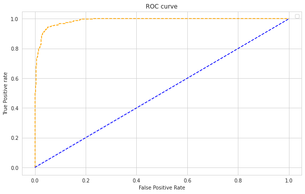

```
--------------------------
|      Best Estimator     |
--------------------------

	LogisticRegression(C=30)

--------------------------
|     Best parameters     |
--------------------------
	Parameters of best estimator :

	{'C': 30, 'penalty': 'l2', 'solver': 'lbfgs'}

---------------------------------
|   No of CrossValidation sets   |
--------------------------------

	Total number of cross validation sets: 3

--------------------------
|        Best Score       |
--------------------------

	Average Cross Validate scores of best estimator :

	0.9420898829062093
```

```python
# start Grid search with scaled data

parameters = {'C':[0.01, 0.1, 1, 10, 20, 30], 'penalty':['l2','l1'], 'solver':['newton-cg', 'lbfgs', 'liblinear', 'sag', 'saga']}
#parameters = {'C':[0.01, 0.1, 1, 10, 20, 30], 'penalty':['l2','l1','elasticnet','none'], 'dual':[True,False], 'tol':[1e-4], 'fit_intercept':[True,False], 'intercept_scaling':[1,2,5,10],
#              'class_weight':[None,'balanced'], 'solver':['newton-cg', 'lbfgs', 'liblinear', 'sag', 'saga'], 'max_iter':[100]}
log_reg = linear_model.LogisticRegression()
log_reg_grid = GridSearchCV(log_reg, param_grid=parameters, cv=3, verbose=1, n_jobs=-1)
log_reg_grid_results = perform_model(log_reg_grid, X_train_scaled_ffs, y_train, X_test_scaled_ffs, y_test, labels)
# observe the attributes of the model
print_grid_search_attributes(log_reg_grid_results)
```

## 13. Naive Bayes with GaussianNB and Grid Search post Forward Subset Selection with Top 20 Features

```
training the model..
Fitting 3 folds for each of 100 candidates, totalling 300 fits
Done


training_time(HH:MM:SS.ms) - 0:00:02.710966


Predicting test data
Done


testing time(HH:MM:SS:ms) - 0:00:00.009992


---------------------
|      Accuracy      |
---------------------

    0.858114233907525


--------------------
| Confusion Matrix |
--------------------

 [[421   0   0   0   0   1]
 [ 24 211 151   0   0   0]
 [  1   6 405   0   0   0]
 [  0   0   0 327  21  20]
 [  0   0   0  19 260  17]
 [  0   0   0  30  23 269]]
```

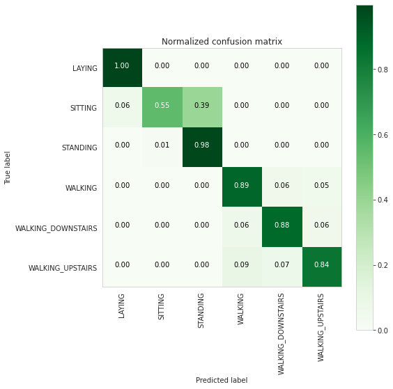

```
No artists with labels found to put in legend.  Note that artists whose label start with an underscore are ignored when legend() is called with no argument.
```

```
-------------------------
| Classifiction Report |
-------------------------
              precision    recall  f1-score   support

           1       0.94      1.00      0.97       422
           2       0.97      0.55      0.70       386
           3       0.73      0.98      0.84       412
           4       0.87      0.89      0.88       368
           5       0.86      0.88      0.87       296
           6       0.88      0.84      0.86       322

    accuracy                           0.86      2206
   macro avg       0.87      0.85      0.85      2206
weighted avg       0.87      0.86      0.85      2206

-------------------------
| ROC Curve |
-------------------------
```

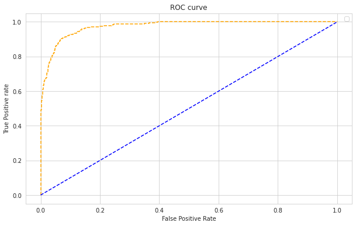

```
--------------------------
|      Best Estimator     |
--------------------------

	GaussianNB(var_smoothing=0.01873817422860384)

--------------------------
|     Best parameters     |
--------------------------
	Parameters of best estimator :

	{'var_smoothing': 0.01873817422860384}

---------------------------------
|   No of CrossValidation sets   |
--------------------------------

	Total number of cross validation sets: 3

--------------------------
|        Best Score       |
--------------------------

	Average Cross Validate scores of best estimator :

	0.8472602227704269
```

```python
# start Grid search with Scaled Data
parameters = {'var_smoothing': np.logspace(0,-9, num=100)}
NB_Gaussian = GaussianNB()
NB_Gaussian_grid = GridSearchCV(NB_Gaussian, param_grid=parameters, cv=3, verbose=1, n_jobs=-1)
NB_Gaussian_grid_results =  perform_model(NB_Gaussian_grid, X_train_scaled_ffs, y_train, X_test_scaled_ffs, y_test, labels)
# observe the attributes of the model
print_grid_search_attributes(NB_Gaussian_grid_results)
```

## 14. Naive Bayes with BernoulliNB and Grid Search post Forward Subset Selection with Top 20 Features

```
training the model..
Fitting 10 folds for each of 50 candidates, totalling 500 fits
Done


training_time(HH:MM:SS.ms) - 0:00:03.988672


Predicting test data
Done


testing time(HH:MM:SS:ms) - 0:00:00.006996


---------------------
|      Accuracy      |
---------------------

    0.7461468721668177


--------------------
| Confusion Matrix |
--------------------

 [[393  29   0   0   0   0]
 [ 84 181 121   0   0   0]
 [  0  88 324   0   0   0]
 [  0   0   0 288  17  63]
 [  0   0   0  22 233  41]
 [  0   0   4  71  20 227]]
```

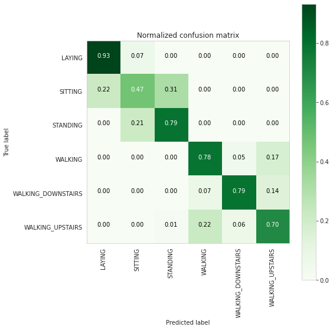

```
No artists with labels found to put in legend.  Note that artists whose label start with an underscore are ignored when legend() is called with no argument.
```

```
-------------------------
| Classifiction Report |
-------------------------
              precision    recall  f1-score   support

           1       0.82      0.93      0.87       422
           2       0.61      0.47      0.53       386
           3       0.72      0.79      0.75       412
           4       0.76      0.78      0.77       368
           5       0.86      0.79      0.82       296
           6       0.69      0.70      0.70       322

    accuracy                           0.75      2206
   macro avg       0.74      0.74      0.74      2206
weighted avg       0.74      0.75      0.74      2206

-------------------------
| ROC Curve |
-------------------------
```

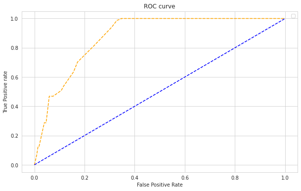

```
--------------------------
|      Best Estimator     |
--------------------------

	BernoulliNB(alpha=0.01, binarize=0.5)

--------------------------
|     Best parameters     |
--------------------------
	Parameters of best estimator :

	{'alpha': 0.01, 'binarize': 0.5, 'class_prior': None, 'fit_prior': True}

---------------------------------
|   No of CrossValidation sets   |
--------------------------------

	Total number of cross validation sets: 10

--------------------------
|        Best Score       |
--------------------------

	Average Cross Validate scores of best estimator :

	0.7275546824827169
```

```python
# start Grid search
parameters = {'alpha':[0.01, 0.1, 0.5, 1.0, 10.0], 'binarize':[0.0, 0.1, 0.5, 1.0, 10.0], 'fit_prior':[True, False], 'class_prior':[None]}
NB_Bernoulli = BernoulliNB()
NB_Bernoulli_grid = GridSearchCV(NB_Bernoulli, param_grid=parameters, cv=10, verbose=1, n_jobs=-1)
NB_Bernoulli_grid_results =  perform_model(NB_Bernoulli_grid, X_train_scaled_ffs, y_train, X_test_scaled_ffs, y_test, labels)
# observe the attributes of the model
print_grid_search_attributes(NB_Bernoulli_grid_results)
```

## 15. Naive Bayes with CategoricalNB and Grid Search post Forward Subset Selection with Top 20 Features

```
training the model..
Fitting 10 folds for each of 72 candidates, totalling 720 fits
Done


training_time(HH:MM:SS.ms) - 0:00:13.782964


Predicting test data
Done


testing time(HH:MM:SS:ms) - 0:00:00.006997


---------------------
|      Accuracy      |
---------------------

    0.19174977334542156


--------------------
| Confusion Matrix |
--------------------

 [[422   0   0   0   0   0]
 [386   0   0   0   0   0]
 [412   0   0   0   0   0]
 [368   0   0   0   0   0]
 [295   0   0   0   1   0]
 [322   0   0   0   0   0]]
```

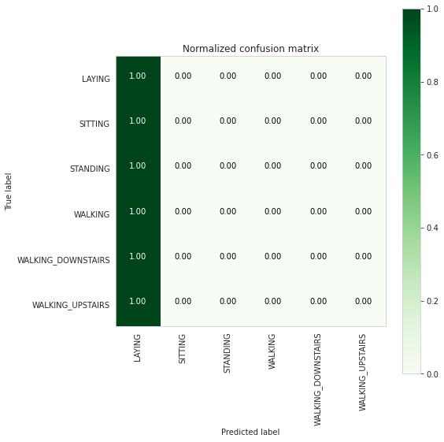

```
No artists with labels found to put in legend.  Note that artists whose label start with an underscore are ignored when legend() is called with no argument.
```

```
-------------------------
| Classifiction Report |
-------------------------
              precision    recall  f1-score   support

           1       0.19      1.00      0.32       422
           2       0.00      0.00      0.00       386
           3       0.00      0.00      0.00       412
           4       0.00      0.00      0.00       368
           5       1.00      0.00      0.01       296
           6       0.00      0.00      0.00       322

    accuracy                           0.19      2206
   macro avg       0.20      0.17      0.05      2206
weighted avg       0.17      0.19      0.06      2206

-------------------------
| ROC Curve |
-------------------------
```

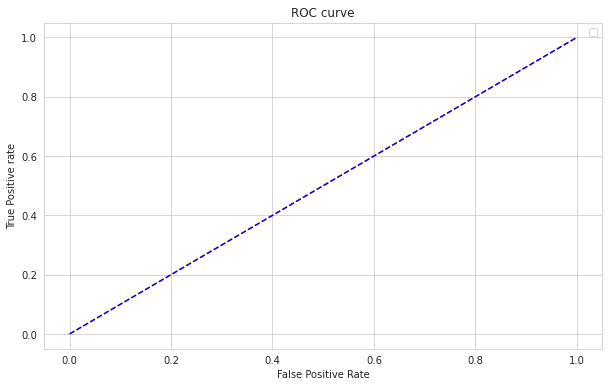

```
--------------------------
|      Best Estimator     |
--------------------------

	CategoricalNB(alpha=10.0, fit_prior=False, min_categories=4)

--------------------------
|     Best parameters     |
--------------------------
	Parameters of best estimator :

	{'alpha': 10.0, 'class_prior': None, 'fit_prior': False, 'min_categories': 4}

---------------------------------
|   No of CrossValidation sets   |
--------------------------------

	Total number of cross validation sets: 10

--------------------------
|        Best Score       |
--------------------------

	Average Cross Validate scores of best estimator :

	0.19179932756601564
```

```python
# start Grid search
parameters = {'alpha':[0.01, 0.1, 0.5, 1.0, 5.0, 10.0], 'min_categories':[1, 2, 3, 4, 5, None], 'fit_prior':[True, False], 'class_prior':[None]}
NB_Categorical = CategoricalNB()
NB_Categorical_grid = GridSearchCV(NB_Categorical, param_grid=parameters, cv=10, verbose=1, n_jobs=-1)
NB_Categorical_grid_results =  perform_model(NB_Categorical_grid, X_train_scaled_ffs, y_train, X_test_scaled_ffs, y_test, labels)
# observe the attributes of the model
print_grid_search_attributes(NB_Categorical_grid_results)
```

## 16. Naive Bayes with ComplementNB and Grid Search post Forward Subset Selection with Top 20 Features

```
training the model..
Fitting 10 folds for each of 24 candidates, totalling 240 fits
Done


training_time(HH:MM:SS.ms) - 0:00:02.350899


Predicting test data
Done


testing time(HH:MM:SS:ms) - 0:00:00.005997


---------------------
|      Accuracy      |
---------------------

    0.5095194922937444


--------------------
| Confusion Matrix |
--------------------

 [[422   0   0   0   0   0]
 [311  75   0   0   0   0]
 [179 227   6   0   0   0]
 [  0   0  87 266  15   0]
 [  0   0   6  23 261   6]
 [  2   3  79  52  92  94]]
```

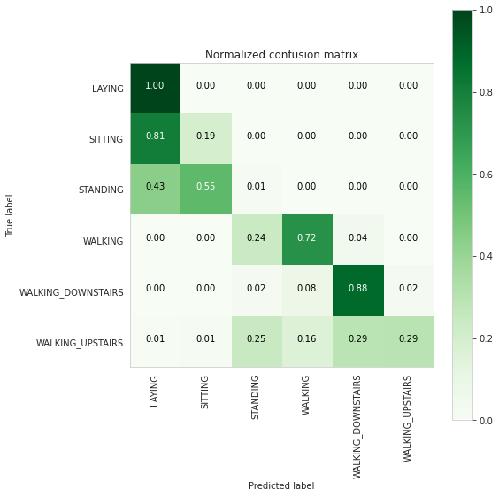

```
No artists with labels found to put in legend.  Note that artists whose label start with an underscore are ignored when legend() is called with no argument.
```

```
-------------------------
| Classifiction Report |
-------------------------
              precision    recall  f1-score   support

           1       0.46      1.00      0.63       422
           2       0.25      0.19      0.22       386
           3       0.03      0.01      0.02       412
           4       0.78      0.72      0.75       368
           5       0.71      0.88      0.79       296
           6       0.94      0.29      0.45       322

    accuracy                           0.51      2206
   macro avg       0.53      0.52      0.48      2206
weighted avg       0.50      0.51      0.46      2206

-------------------------
| ROC Curve |
-------------------------
```

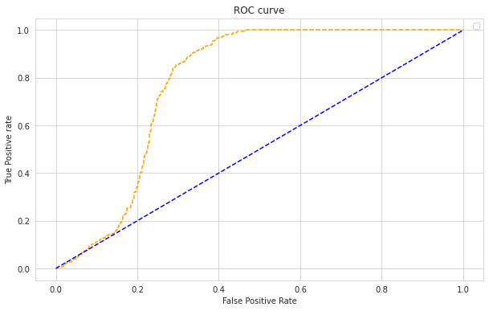

```
--------------------------
|      Best Estimator     |
--------------------------

	ComplementNB(alpha=5.0, norm=True)

--------------------------
|     Best parameters     |
--------------------------
	Parameters of best estimator :

	{'alpha': 5.0, 'class_prior': None, 'fit_prior': True, 'norm': True}

---------------------------------
|   No of CrossValidation sets   |
--------------------------------

	Total number of cross validation sets: 10

--------------------------
|        Best Score       |
--------------------------

	Average Cross Validate scores of best estimator :

	0.4959227078689887
```

```python
# start Grid search
parameters = {'alpha':[0.01, 0.1, 0.5, 1.0, 5.0, 10.0], 'norm':[True, False], 'fit_prior':[True, False], 'class_prior':[None]}
NB_Complement = ComplementNB()
NB_Complement_grid = GridSearchCV(NB_Complement, param_grid=parameters, cv=10, verbose=1, n_jobs=-1)
NB_Complement_grid_results =  perform_model(NB_Complement_grid, X_train_scaled_ffs, y_train, X_test_scaled_ffs, y_test, labels)
# observe the attributes of the model
print_grid_search_attributes(NB_Complement_grid_results)
```

## 17. Naive Bayes with MultinomialNB and Grid Search post Forward Subset Selection with Top 20 Features

```
training the model..
Fitting 10 folds for each of 12 candidates, totalling 120 fits
Done


training_time(HH:MM:SS.ms) - 0:00:01.416187


Predicting test data
Done


testing time(HH:MM:SS:ms) - 0:00:00.005997


---------------------
|      Accuracy      |
---------------------

    0.8032638259292838


--------------------
| Confusion Matrix |
--------------------

 [[358  60   0   0   0   4]
 [ 30 259  92   3   0   2]
 [  1  89 314   7   0   1]
 [  0   0   0 324  21  23]
 [  0   0   0  17 254  25]
 [  0   0   0   8  51 263]]
```

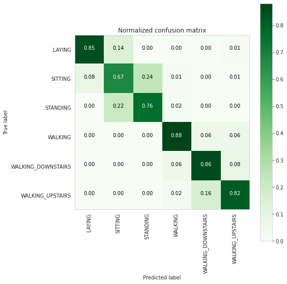

```
No artists with labels found to put in legend.  Note that artists whose label start with an underscore are ignored when legend() is called with no argument.
```

```
-------------------------
| Classifiction Report |
-------------------------
              precision    recall  f1-score   support

           1       0.92      0.85      0.88       422
           2       0.63      0.67      0.65       386
           3       0.77      0.76      0.77       412
           4       0.90      0.88      0.89       368
           5       0.78      0.86      0.82       296
           6       0.83      0.82      0.82       322

    accuracy                           0.80      2206
   macro avg       0.81      0.81      0.81      2206
weighted avg       0.81      0.80      0.80      2206

-------------------------
| ROC Curve |
-------------------------
```

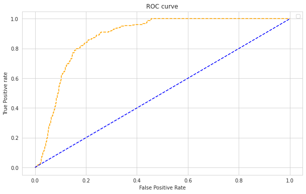

```
--------------------------
|      Best Estimator     |
--------------------------

	MultinomialNB(fit_prior=False)

--------------------------
|     Best parameters     |
--------------------------
	Parameters of best estimator :

	{'alpha': 1.0, 'class_prior': None, 'fit_prior': False}

---------------------------------
|   No of CrossValidation sets   |
--------------------------------

	Total number of cross validation sets: 10

--------------------------
|        Best Score       |
--------------------------

	Average Cross Validate scores of best estimator :

	0.8025688489290166
```

```python
# start Grid search
parameters = {'alpha':[0.01, 0.1, 0.5, 1.0, 5.0, 10.0], 'fit_prior':[True, False], 'class_prior':[None]}
NB_Multinomial = MultinomialNB()
NB_Multinomial_grid = GridSearchCV(NB_Multinomial, param_grid=parameters, cv=10, verbose=1, n_jobs=-1)
NB_Multinomial_grid_results =  perform_model(NB_Multinomial_grid, X_train_scaled_ffs, y_train, X_test_scaled_ffs, y_test, labels)
# observe the attributes of the model
print_grid_search_attributes(NB_Multinomial_grid_results)
```

## 18. K-Nearest Neighbours and Grid Search post Forward Subset Selection with Top 20 Features

```
training the model..
Fitting 3 folds for each of 56 candidates, totalling 168 fits
Done


training_time(HH:MM:SS.ms) - 0:00:26.726749


Predicting test data
Done


testing time(HH:MM:SS:ms) - 0:00:01.135503


---------------------
|      Accuracy      |
---------------------

    0.9514959202175884


--------------------
| Confusion Matrix |
--------------------

 [[421   0   0   0   0   1]
 [  1 322  63   0   0   0]
 [  0  31 381   0   0   0]
 [  0   0   0 366   1   1]
 [  0   0   0   2 292   2]
 [  0   0   0   3   2 317]]
```

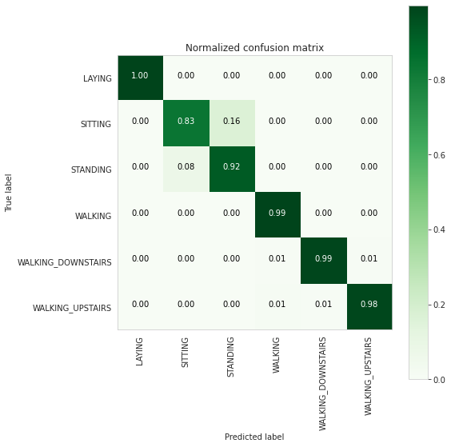

```
-------------------------
| Classifiction Report |
-------------------------
              precision    recall  f1-score   support

           1       1.00      1.00      1.00       422
           2       0.91      0.83      0.87       386
           3       0.86      0.92      0.89       412
           4       0.99      0.99      0.99       368
           5       0.99      0.99      0.99       296
           6       0.99      0.98      0.99       322

    accuracy                           0.95      2206
   macro avg       0.96      0.95      0.95      2206
weighted avg       0.95      0.95      0.95      2206

-------------------------
| ROC Curve |
-------------------------
```

```
No artists with labels found to put in legend.  Note that artists whose label start with an underscore are ignored when legend() is called with no argument.
```

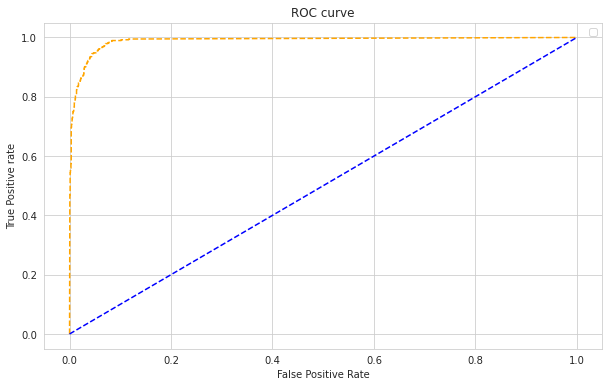

```
--------------------------
|      Best Estimator     |
--------------------------

	KNeighborsClassifier(n_neighbors=15, weights='distance')

--------------------------
|     Best parameters     |
--------------------------
	Parameters of best estimator :

	{'algorithm': 'auto', 'leaf_size': 30, 'metric': 'minkowski', 'n_neighbors': 15, 'p': 2, 'weights': 'distance'}

---------------------------------
|   No of CrossValidation sets   |
--------------------------------

	Total number of cross validation sets: 3

--------------------------
|        Best Score       |
--------------------------

	Average Cross Validate scores of best estimator :

	0.9547219220688609
```

```python
# start Grid search
#parameters = {'n_neighbors':[5.10,15,20,25,30,35,40], 'weights':['uniform', 'distance'], 'algorithm':['auto', 'ball_tree', 'kd_tree', 'brute'], 'leaf_size':[20,30,40], 'p':[1,2,3],
#              'metric':['euclidean', 'manhattan', 'chebyshev','minkowski','wminkowski','seuclidean','mahalanobis']}
parameters = {'n_neighbors':[5.10,15,20,25,30,35,40], 'weights':['uniform', 'distance'], 'algorithm':['auto', 'ball_tree', 'kd_tree', 'brute'], 'leaf_size':[30], 'p':[2],
              'metric':['minkowski']}
K_NN = KNeighborsClassifier()
K_NN_grid = GridSearchCV(K_NN, param_grid=parameters, cv=3, verbose=1, n_jobs=-1)
K_NN_grid_results =  perform_model(K_NN_grid, X_train_scaled_ffs, y_train, X_test_scaled_ffs, y_test, labels)
# observe the attributes of the model
print_grid_search_attributes(K_NN_grid_results)
```

# Compare time and accuracy of different algos

```python
dFFeature_Subset_Result.drop(dFFeature_Subset_Result.index, inplace=True)

for item in Feature_Subset_Result:
    dFFeature_Subset_Result.loc[dFFeature_Subset_Result.shape[0]] = item

print(dFFeature_Subset_Result[['Best Estimator', 'Training Time', 'Testing Time', 'Overall Accuracy of Model',
                                                'Average Cross Validate scores of best estimator']].to_markdown())
```

```
|    | Best Estimator                                               | Training Time          | Testing Time           |   Overall Accuracy of Model |   Average Cross Validate scores of best estimator |
|---:|:-------------------------------------------------------------|:-----------------------|:-----------------------|----------------------------:|--------------------------------------------------:|
|  0 | LogisticRegression(C=10, solver='liblinear')                 | 0 days 00:11:07.399354 | 0 days 00:00:00.008994 |                    0.985494 |                                          0.982705 |
|  1 | GaussianNB(var_smoothing=0.02848035868435802)                | 0 days 00:00:39.714497 | 0 days 00:00:00.160908 |                    0.834995 |                                          0.832687 |
|  2 | BernoulliNB(alpha=0.1, binarize=0.5)                         | 0 days 00:00:31.498527 | 0 days 00:00:00.044973 |                    0.838169 |                                          0.837553 |
|  3 | CategoricalNB(alpha=0.01, fit_prior=False, min_categories=2) | 0 days 00:03:57.636146 | 0 days 00:00:00.079955 |                    0.203536 |                                          0.192187 |
|  4 | ComplementNB(alpha=10.0)                                     | 0 days 00:00:11.416918 | 0 days 00:00:00.005999 |                    0.568903 |                                          0.577338 |
|  5 | MultinomialNB(alpha=10.0, fit_prior=False)                   | 0 days 00:00:06.086807 | 0 days 00:00:00.007998 |                    0.855848 |                                          0.844934 |
|  6 | KNeighborsClassifier(n_neighbors=15, weights='distance')     | 0 days 00:05:30.608420 | 0 days 00:00:02.465188 |                    0.956936 |                                          0.952001 |
|  7 | LogisticRegression(C=10, penalty='l1', solver='saga')        | 0 days 00:02:49.663472 | 0 days 00:00:00.000999 |                    0.971442 |                                          0.965798 |
|  8 | GaussianNB(var_smoothing=0.0002848035868435802)              | 0 days 00:00:06.350876 | 0 days 00:00:00.028995 |                    0.907525 |                                          0.89759  |
|  9 | BernoulliNB(fit_prior=False)                                 | 0 days 00:00:02.165755 | 0 days 00:00:00.012993 |                    0.8767   |                                          0.866888 |
| 10 | KNeighborsClassifier(n_neighbors=15, weights='distance')     | 0 days 00:00:53.464397 | 0 days 00:00:00.654623 |                    0.953309 |                                          0.947725 |
| 11 | LogisticRegression(C=30)                                     | 0 days 00:01:07.605400 | 0 days 00:00:00.004998 |                    0.939257 |                                          0.94209  |
| 12 | GaussianNB(var_smoothing=0.01873817422860384)                | 0 days 00:00:02.710966 | 0 days 00:00:00.009992 |                    0.858114 |                                          0.84726  |
| 13 | BernoulliNB(alpha=0.01, binarize=0.5)                        | 0 days 00:00:03.988672 | 0 days 00:00:00.006996 |                    0.746147 |                                          0.727555 |
| 14 | CategoricalNB(alpha=10.0, fit_prior=False, min_categories=4) | 0 days 00:00:13.782964 | 0 days 00:00:00.006997 |                    0.19175  |                                          0.191799 |
| 15 | ComplementNB(alpha=5.0, norm=True)                           | 0 days 00:00:02.350899 | 0 days 00:00:00.005997 |                    0.509519 |                                          0.495923 |
| 16 | MultinomialNB(fit_prior=False)                               | 0 days 00:00:01.416187 | 0 days 00:00:00.005997 |                    0.803264 |                                          0.802569 |
| 17 | KNeighborsClassifier(n_neighbors=15, weights='distance')     | 0 days 00:00:26.726749 | 0 days 00:00:01.135503 |                    0.951496 |                                          0.954722 |
```

### Basis this the model with the best accuracy level is '0' i.e. LogisticRegression(C=10) without PCA

# Plot confusion Matrix for the final model selected [Marks:1]

```python
#  Model Selected
print('---------------------------------')
print('|          Model Selected       |')
print('--------------------------------\n\n')

dfSelectedModel = dFFeature_Subset_Result[dFFeature_Subset_Result['Overall Accuracy of Model'] == dFFeature_Subset_Result['Overall Accuracy of Model'].max()]

print(dfSelectedModel[['Best Estimator', 'Training Time', 'Testing Time', 'Overall Accuracy of Model',
                                                'Average Cross Validate scores of best estimator']].to_markdown())
#dFFeature_Subset_Result.loc[dFFeature_Subset_Result['Overall Accuracy of Model'].idxmax()]
#dFFeature_Subset_Result.loc[dFFeature_Subset_Result['Overall Accuracy of Model'].idxmax()].values[0]

#  Confusion Matrix
print('\n\n---------------------------------')
print('|          Confusion Matrix     |')
print('--------------------------------\n\n')
print(dfSelectedModel[['Confusion Matrix']].to_markdown())

#dfSelectedModel
```

```
---------------------------------
|          Model Selected       |
--------------------------------


|    | Best Estimator                               | Training Time          | Testing Time           |   Overall Accuracy of Model |   Average Cross Validate scores of best estimator |
|---:|:---------------------------------------------|:-----------------------|:-----------------------|----------------------------:|--------------------------------------------------:|
|  0 | LogisticRegression(C=10, solver='liblinear') | 0 days 00:11:07.399354 | 0 days 00:00:00.008994 |                    0.985494 |                                          0.982705 |


---------------------------------
|          Confusion Matrix     |
--------------------------------


|    | Confusion Matrix            |
|---:|:----------------------------|
|  0 | [[422   0   0   0   0   0]  |
|    |  [  0 369  17   0   0   0]  |
|    |  [  0  14 398   0   0   0]  |
|    |  [  0   0   0 368   0   0]  |
|    |  [  0   0   0   0 296   0]  |
|    |  [  0   0   0   1   0 321]] |
```

# Plot ROC Curve for the final model [Marks:1]

An ROC curve (receiver operating characteristic curve) is a graph showing the performance of a classification model at all classification thresholds. This curve plots two parameters:

- True Positive Rate
- False Positive Rate

```
No artists with labels found to put in legend.  Note that artists whose label start with an underscore are ignored when legend() is called with no argument.
```

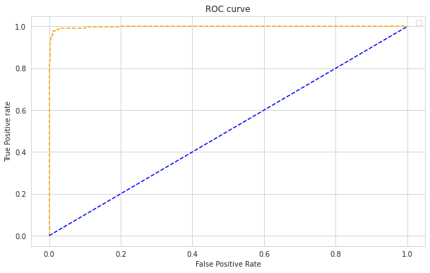

```python
fpr_array = dfSelectedModel['FPR'].values
fpr_array  = [val for sublist in fpr_array for val in sublist]

tpr_array = dfSelectedModel['TPR'].values
tpr_array  = [val for sublist in tpr_array for val in sublist]

p_fpr_array = dfSelectedModel['P_FPR'].values
p_fpr_array  = [val for sublist in p_fpr_array for val in sublist]

p_tpr_array = dfSelectedModel['P_TPR'].values
p_tpr_array  = [val for sublist in p_tpr_array for val in sublist]

# plot roc curves
plt.plot(fpr_array, tpr_array, linestyle='--',color='orange', label="")
plt.plot(p_fpr_array, p_tpr_array, linestyle='--', color='blue')
# title
plt.title('ROC curve')
# x label
plt.xlabel('False Positive Rate')
# y label
plt.ylabel('True Positive rate')
plt.legend(loc='best')
plt.savefig('ROC',dpi=300)
plt.rcParams['figure.figsize'] = [10, 6]
plt.show();
```